# univariate models

First created on 2015-02-01. Updated on 2025-02-10

Home Page - http://dmcglinn.github.io/quant_methods/ GitHub Repo - https://github.com/dmcglinn/quant_methods

### Source Code Link

https://raw.githubusercontent.com/dmcglinn/quant_methods/gh-pages/lessons/univariate_models.Rmd

The goals of this lesson are to introduce univariate modeling using simple and multivariate Ordinary Least Squares (OLS) regression, and to gain exposure to the concept and methods of model comparison.

The content from this lesson is modified in part from lessons developed by Jack Weiss and Jason Fridley. The original lessons can be found at the following links:

- [Weiss 2012](https://sakai.unc.edu/access/content/group/3d1eb92e-7848-4f55-90c3-7c72a54e7e43/public/docs/lectures/lecture1.htm)
- [Fridley 2010](http://plantecology.syr.edu/fridley/bio793/lm.html)

## Readings and Literature Cited

- Chapters 5, 9-10 in *The R book* (1st ed) by Crawley
- Chapters 6 in *MASS* (4th ed) by Venables and Ripley
- Chapter 1 in *Model Selection and Multimodel Inference* (2nd ed) by Burnham and Anderson
- p150 in *A primer of Ecological Statistics* (2nd ed) by Gotelli and Ellison

## Lesson Outline

- Modeling Philosophy
- The Milkweeds and Fertilizer Example
- Model Building and Graphing
- Tabular Model Interpretation
- Understanding Regression via Simulation

## # Modeling Philosophy

One of the simplest and most important ideas when constructing models can be stated succinctly:

> “All models are wrong but some models are useful” G.E. Box

As scientists we have to be on guard that we are not too attached to our models. Additionally it is often difficult to decide when a model is useful or not because there are three general reasons for building a model:

- Hypothesis testing
- Exploring data
- Predicting data

These different goals of model building require different approaches and modes of model evaluation. Hypothesis testing is typically geared towards testing a small handful of carefully crafted *A PRIORI* hypotheses. In this context the model is typically judged useful if it is statistically significant.  
However, many times though the investigator does not have a clear *a priori* hypothesis [(see post at Small Pond Science)](http://smallpondscience.com/2013/06/04/pretending-you-planned-to-test-that-hypothesis-the-whole-time/) and is instead examining if a large number of possibly relevant variables are correlated with a response of interest. The goal of this kind of exploratory analysis is to generate hypotheses that can be more carefully tested with **other datasets** and not with the dataset used to generate them. Unfortunately very frequently and quite misleadingly the correlations that are found to be strong in the exploratory analysis are then presented in a hypo-deductive framework as if they were *a prori* [(see post on Dynamic Ecology)](https://dynamicecology.wordpress.com/2013/10/16/in-praise-of-exploratory-statistics/). When using models to make predictions we are typically less concerned about the exact variables that are in the model and more concerned that we can predict observations not included in the building of the model (i.e., cross-validate the model).

There are many reasons that p-values and statistical significance are abused in science. For example, it can be very tempting to report statistics of significance in many analyses in which you did not have clear *a prori* hypotheses because often times R will report such statistics without prompting from the user (e.g., `summary(my_ols_model)`). Additionally there is a stigma in many fields of science against exploratory analyses in favor of hypothesis testing which pushes some researchers to re-frame their analyses as if they are confirmatory rather than exploratory. And of course there is pressure during peer-review to only report on statistics that are significant.

You might be wondering why this is a big deal. The reason is Freedman’s paradox [(Freedman 1983)](http://amstat.tandfonline.com/doi/abs/10.1080/00031305.1983.10482729#.Ul17gVAkJPQ) which demonstrates that you will inevitably get good fitting models (high R^2) and statistically significant results (p < 0.05) if you keep adding variables to a model even if those variables by definition are independent of the response variable. The solution to Freedman’s paradox is to approach model comparison as carefully and intentionally as possible with a small number of deliberately chosen models. Burnham and Anderson (2002, p19) advocate for:

> … a conservative approach to the overall issue of *strategy* in the analysis of data in the biological sciences with an emphasis on *a priori* considerations and models to be considered. *Careful, a priori consideration of alternative models will often require a major change in emphasis among many people.*

### The Principle of Parsimony (Occam’s Razor)

Once you have decided on a small number of models to compare how do you decide which model is the best? One approach is to use the principle of parsimony which can be stated succinctly as:

> the correct explanation is the simplest explanation that is sufficient.

For our purposes we can think of this as:

> the model with the smallest possible number of parameters for adequate representation of the data (Box and Jenkins 1970)

Crawley (2007) suggested that all else being equal the better model is the model with the following properties:

- a model with n−1 parameters to a model with n parameters;
- a model with k−1 explanatory variables to a model with k explanatory variables;
- a linear model to a model which is curved;
- a model without a hump to a model with a hump;
- a model without interactions to a model containing interactions between factors.

Thus model simplification is an important part of finding the most useful model. A simpler model that explains similar levels of deviance in a response should be considered a better model.

Crawley (2007) suggests the following steps for backward model simplification:

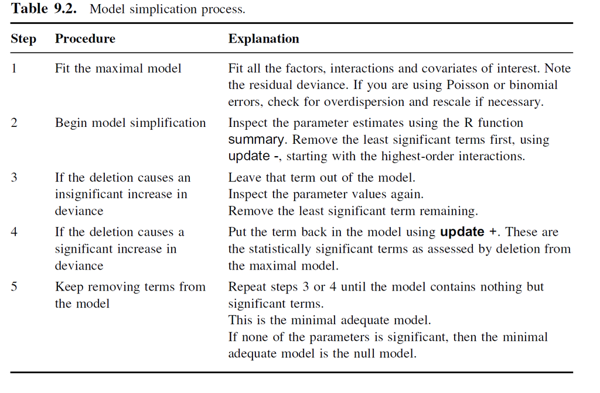

These steps are reasonable if one is carrying out an **exploratory** data analysis; however, I do not recommend this approach when formal hypothesis testing is the goal of the analysis due to Freedman’s paradox as explained above. Other methods of model selection (other than p < 0.05 as advocated above) will suffer the same problem.

According to Burnham and Anderson (2002, p18) to resolve Freedman’s paradox one should:  
1) use biologically meaningful models  
2) keep the number of candidate models small  
3) have a large sample size relative to the number of parameters to be estimated  
4) base inference on more than one model (multi-model inference) if models perform equally well

In regards to #3 above, Gotelli and Ellison (2018, p150) suggest *The Rule of 10*: *you should have at least 10 replicate observations per treatment level or variable included in the model.*

Last point regarding model building is that it is also possible to proceed from simple to more complex models as well evaluating with each additional term if it has significantly increased explanatory power.

## # The Milkweeds and Fertilizer Example

We will begin exploring how to build and interpret linear models in R by using a data set that a researcher collected 40 plants of common milkweed, *Asclepias syriaca*, from old fields in northeastern Maine and grew them in a greenhouse; 20 received fertilizer and the other 20 were kept as controls. After two months, she measured the height of each plant and then collected and weighed all of the fruit produced by the plant.

For today’s purposes we will examine how fruit mass responses to fertilization, and plant height, and if fertilization modulates the effect of plant height on fruit mass.

First let’s read load the relevant R packages and the data in and look at the structure of the data

```r
#install.packages("ggplot2")
#install.packages("gridExtra")
#install.packages("scatterplot3d")
#install.packages("MASS")
#install.packages("marginaleffects")

library(ggplot2)          # to make fancy graphs
library(gridExtra)        # arrange ggplot graphs
library(scatterplot3d)    # make 3d plot
library(MASS)             # for stepAIC to automate model selection
library(marginaleffects)  # to plot model predictions
```

Now that we have our libraries loaded let’s read in the data

```r
weeds <- read.csv('http://dmcglinn.github.io/quant_methods/data/milkweeds.csv',
                  colClasses = c('integer', 'factor', 'numeric', 'numeric'))
weeds
```

```
##    samp_id          trt plant_ht_cm fruit_mass_mg
## 1        1   fertilized       30.32         19.17
## 2        2 unfertilized       23.07         15.06
## 3        3   fertilized       21.90         16.09
## 4        4 unfertilized       32.32         17.19
## 5        5 unfertilized       30.19         15.88
## 6        6   fertilized       19.63         18.91
## 7        7 unfertilized       15.32         13.43
## 8        8   fertilized       25.26         15.54
## 9        9   fertilized       25.42         22.90
## 10      10   fertilized       22.33         15.97
## 11      11   fertilized       36.81         24.80
## 12      12 unfertilized       23.76         17.18
## 13      13   fertilized       22.75         22.00
## 14      14   fertilized       32.29         19.31
```

[output cut: 26 more lines]

So we can see that this data set is fairly simple. There are two treatments in the column called `trt`: `fertilized` and `unfertilized`. And there are two continuous variables plant height is provided by `plant_ht_cm` and fruit mass by `fruit_mass_mg`.

Before we dive into the models it is always important to **first visually examine the patterns in the data set graphically**. This will help to build our intuition which will guide our modeling and interpretation of the statistics.

> A quick note on graphics. I will primarily use base graphics in this course but increasingly the R community is moving towards using `ggplot` for graphics. `ggplot` is a really great set of tools for making beautiful graphics but it can be more difficult to understand exactly how it works and how to custumize graphics. Therefore, I want to expose you to both methods of producing graphics the simple and clunky base graphics and the elegent and shiny `ggplot` graphics.

First let’s examine the effect that fertilizer has on fruit mass using box-and-whisker plots.

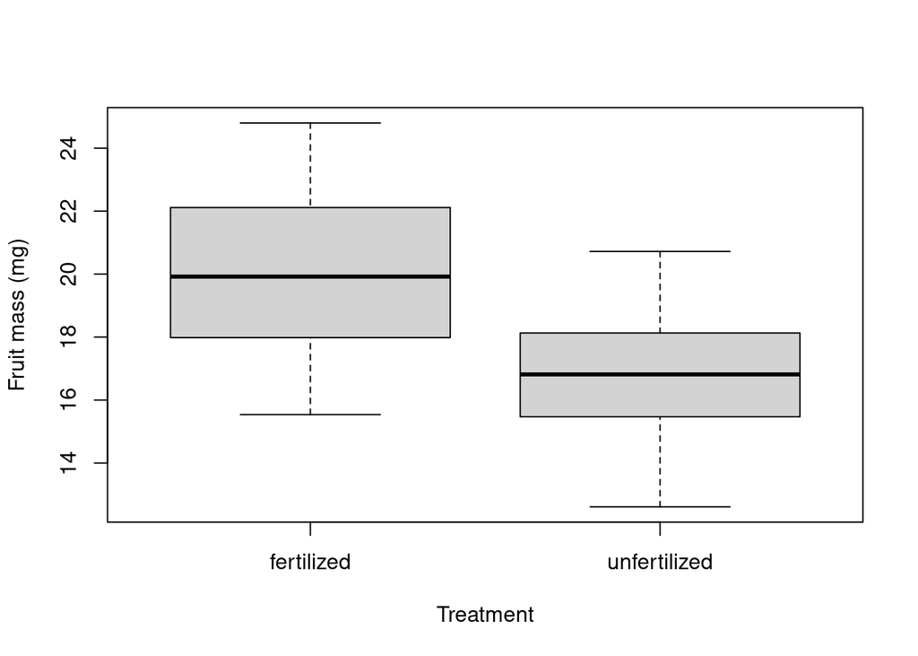

```r
boxplot(fruit_mass_mg ~ trt, data = weeds, xlab='Treatment',
        ylab = 'Fruit mass (mg)')
```

Above we used the function `boxplot` to produce a modified box-and-whisker plot. In this case we used the `formula` argument to specify the relationship we wished to display in which the LHS is the dependent variable and the RHS is the independent variable. The argument `data` tells the function where to look for the variables that I specified in the `formula` argument. Lastly, `xlab` and `ylab` allow you to specify the labels for each axis.

In the graphic, the box represents the inner quartile range (IQR), the line is the median, and the whiskers represents either the minimum or maximum or 1.5 * IQR which ever is closer to the median value. Outliers are defined as points that fall outside of the whiskers and will be shown as points.

I prefer box-and-whisker plots because they help to represent the data in a summarized way that does not make distributional assumptions. It is also easy to calculate the values used in the boxplot using the function `quantile`

```r
quantile(weeds$fruit_mass_mg[weeds$trt == 'fertilized'])
```

```
##      0%     25%     50%     75%    100%
## 15.5400 18.4475 19.9200 22.0575 24.8000
```

Now let’s make the same graphic using `ggplot`

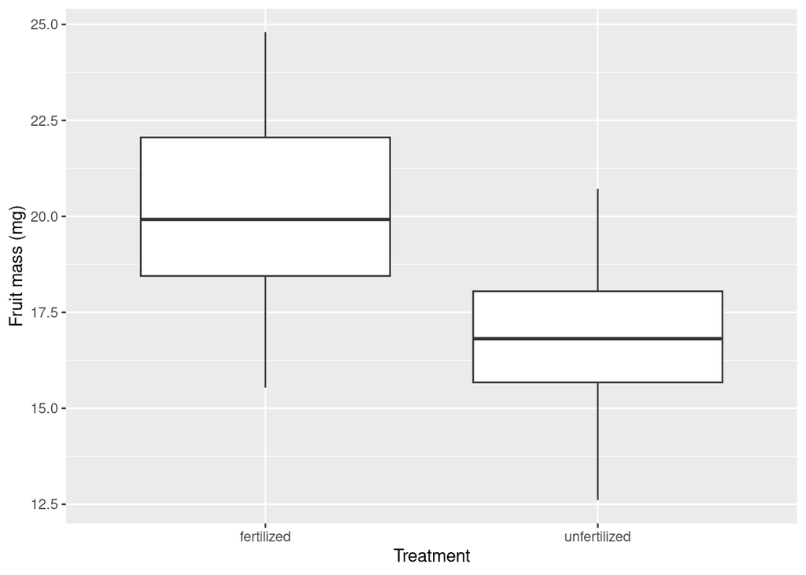

```r
ggplot(data = weeds) +
  geom_boxplot(mapping = aes(x = trt, y = fruit_mass_mg)) +
  labs(x = 'Treatment', y = 'Fruit mass (mg)')
```

Technically this is the same graphic as produced by base but you can see that the R code is a bit more cryptic.

Let’s break it down line by line: `ggplot(data = weeds) +` spawns a `ggplot` graphic and specifies that the data will be provided by the object `weeds`. Now we can simply refer to column names of `weeds` in the remainder of the plotting call.

The next line: `geom_boxplot(mapping = aes(x = trt, y = fruit_mass_mg)) +` specifies the geometry of the graphic in this case a boxplot, there are many other that can be specified in `ggplot`. The geometry function requires a few arguments including how to map data on to the graphic using the argument `mapping`. The mapping is usually wrapped in the function `aes` which provides an aesthetically pleasing rendering of the data on the graphic, `aes` requires and `x` and `y` variables.

The last line: `labs(x = 'Treatment', y = 'Fruit mass (mg)')` provides the axis labels.

Note that each line that is not the last line of the `ggplot` function ends with a plus sign `+` this tells R that you are specifying more options to the plot.

The additional overhead of the understanding this somewhat cryptic R code comes when you want to quickly make nice graphics across multiple factors or splits or a data set and when you want more complex geometries which the `ggplot` developers have already created.

We are only going to touch on the capacities of `ggplot` here. Here are a couple of great places to learn more about `ggplot`

- https://ggplot2.tidyverse.org/
- [*R for Data Science*](https://r4ds.had.co.nz/) by Garrett Grolemund and Hadley Wickham

From our boxplot we can see that fertilizer does seem to increase the mass of the milkweed fruits. Let’s also examine if plant height seems to influence fruit mass.

Since fruit mass and plant height are both continuous variables we will use a scatterplot to display their relationship.

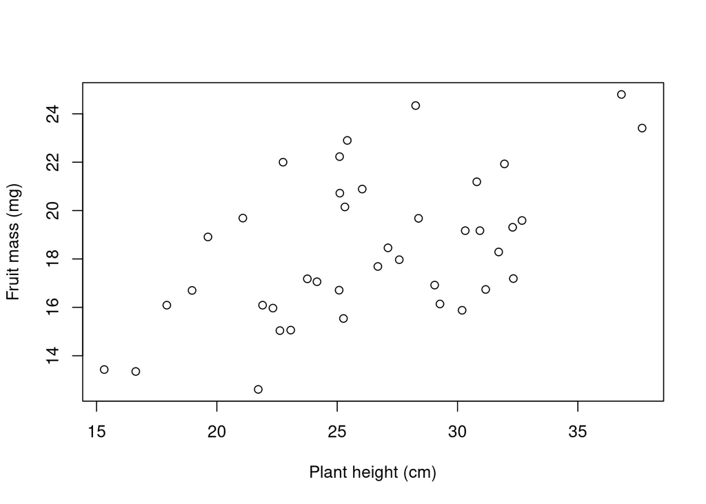

```r
plot(fruit_mass_mg ~ plant_ht_cm, data = weeds, xlab = 'Plant height (cm)',
     ylab = 'Fruit mass (mg)')
```

Like the `boxplot` function the `plot` function allows you to use a `formula` argument to specify the variables included in the plot.

From our plot we can see that taller plants do seem to produce more fruit mass.

Let’s visually examine if fertilizer modifies how fruit mass response to plant height

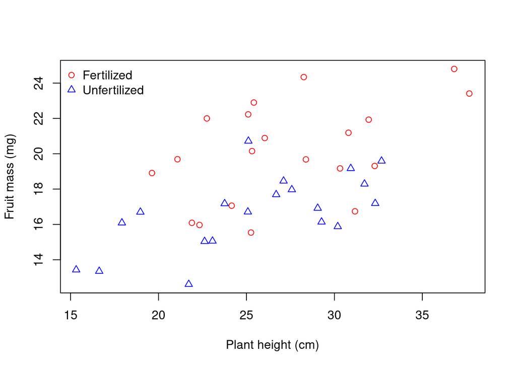

```r
plot(fruit_mass_mg ~ plant_ht_cm, data = weeds, type = 'n',
     xlab = 'Plant height (cm)', ylab = 'Fruit mass (mg)')
points(fruit_mass_mg ~ plant_ht_cm, data = weeds, subset = trt == "fertilized",
       pch = 1, col = 'red')
points(fruit_mass_mg ~ plant_ht_cm, data = weeds, subset = trt == "unfertilized",
       pch = 2, col = 'blue')
legend('topleft', c('Fertilized', 'Unfertilized'), col = c('red', 'blue'),
       pch = c(1, 2), bty = 'n')
```

Now we have a graphic where we have different colors and symbols for the fertilized and unfertilized points.

Let’s add a smoother so that we can better see if the different fertilization regimes have different functional forms. There are many options for smoothing functions to choose from in R but for simplicity we’ll use the function `lowess` which is a locally-weighted polynomial regression.

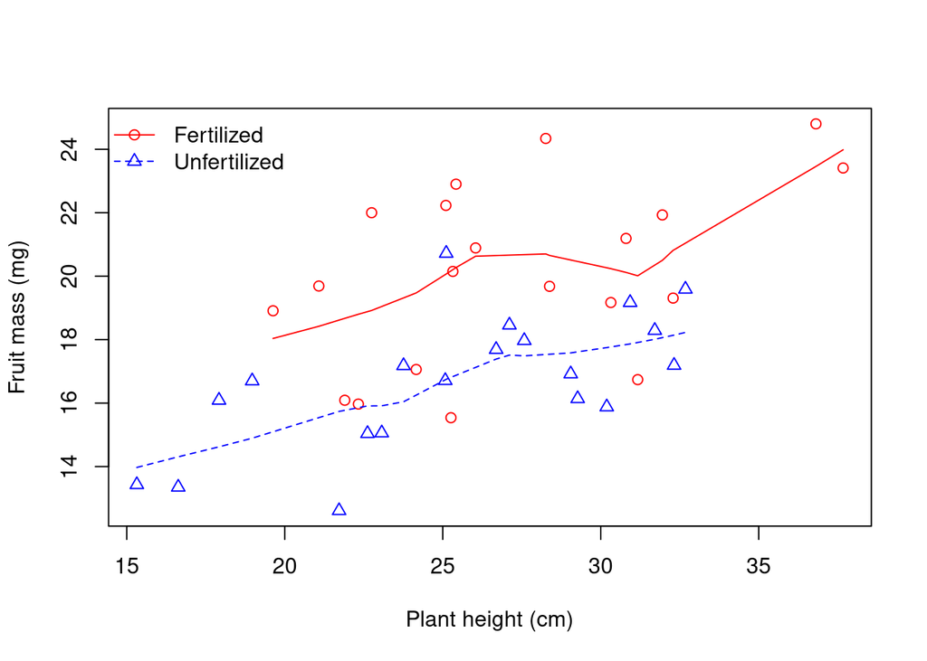

```r
plot(fruit_mass_mg ~ plant_ht_cm, data = weeds, type = 'n',
     xlab = 'Plant height (cm)', ylab = 'Fruit mass (mg)')
points(fruit_mass_mg ~ plant_ht_cm, data = weeds, subset = trt == "fertilized",
       pch = 1, col = 'red')
lines(lowess(weeds$plant_ht_cm[weeds$trt == 'fertilized'],
             weeds$fruit_mass_mg[weeds$trt == 'fertilized']),
      lty = 1, col = 'red')
points(fruit_mass_mg ~ plant_ht_cm, data = weeds, subset = trt == "unfertilized",
       pch = 2, col = 'blue')
lines(lowess(weeds$plant_ht_cm[weeds$trt == 'unfertilized'],
             weeds$fruit_mass_mg[weeds$trt == 'unfertilized']),
      lty = 2, col = 'blue')
legend('topleft', c('Fertilized', 'Unfertilized'), col = c('red', 'blue'),
       pch = c(1, 2), lty = c(1, 2), bty = 'n')
```

##### **Question**

Based on the graphic above does it appear that fertilization modulates the effect of plant height on fruit mass? In statistics we would consider such an effect and **interaction effect**.

[Show answer]

```
There does not appear to be an interaction effect between fruit mass and
fertizlation because the two smoothers look roughly parallel to one another.
This suggests that a model in which just two main effects: treatment and plant
height but no interaction effect is likely going to provide the best
approximation to the data without over fitting.
```

Let’s create the same graphic but using `ggplot`

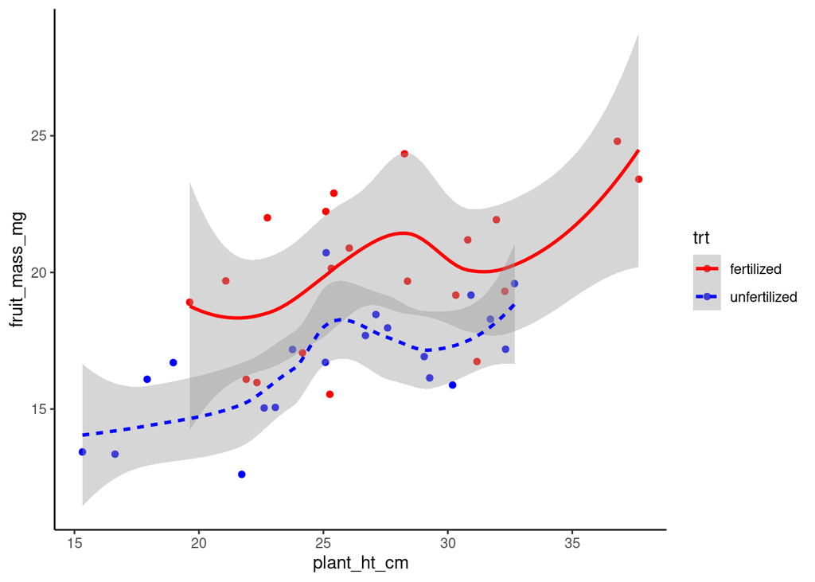

```r
ggplot(data = weeds, mapping = aes(x = plant_ht_cm, y = fruit_mass_mg)) +
  geom_point(mapping = aes(color = trt)) +
  geom_smooth(mapping = aes(linetype = trt, color = trt), method = 'loess') +
  scale_color_manual(values = c("red", "blue")) +
  theme_classic()
```

##### Excercise

Modify the `ggplot` call so that the `x` and `y` axes are properly labeled.

[Show answer]

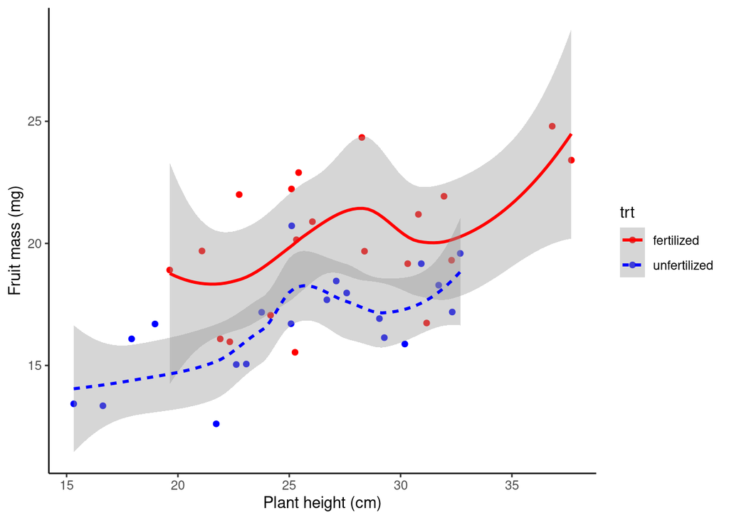

```r
ggplot(data = weeds, mapping = aes(x = plant_ht_cm, y = fruit_mass_mg)) +
  geom_point(mapping = aes(color = trt)) +
  geom_smooth(mapping = aes(linetype = trt, color = trt), method = 'loess') +
  scale_color_manual(values = c("red", "blue")) +
  labs(x = 'Plant height (cm)', y = 'Fruit mass (mg)') +
  theme_classic()
```

## # Model Building and Graphing

Now that we’ve visually explored the relationships in the milkweed data set, and we have developed some intuition about how we might want to approach this data set let’s actually develop some statistical regression models to explain the variation in fruit mass.

### Ordinary Least Squares Regression

Ordinary Least Squares (OLS) regression is one of the most commonly used models in statistics. It attempts to approximate the response variable *y* using a linear combination of explanatory variables **x**. We can express OLS regression algebraically as:

$$y_i = \beta_0 1 + \beta_1 x_{i1} +
\cdots + \beta_p x_{ip} + \varepsilon_i, \qquad i = 1, \ldots, n, \qquad
\varepsilon \sim N(0, \sigma^2) \qquad \text{(equ. 1)}$$

Let’s break equ. 1 down into its parts:

- $y_i$ is the *i*-th value of the response variable
- $\beta_0$ is the *y*-intercept
- the $\beta$ values are the partial slopes of the *p* explanatory variables.
- $\varepsilon$ represents the normally distributed error with mean of 0 and variance equal to $\sigma^2$

One of the core things to take away from equ. 1 is that regression equations always have one or more error terms. How this error is specified (e.g., Normal error, Binomial error, Poisson error) is the key way different regression methods differ from one another. Another important point about the error term is that in OLS each of the *n* samples are assumed to be **independent and identically distributed** (iid) from one another. Other methods of regression we examine (e.g., spatial regression) will not make this same assumption and will specify how samples co-vary with one another.

Taken together it can be seen that OLS regression has a number of key assumptions

1. Linearity such that *y* is a linear combination of the *x*-variables. Because the *x* variables may be transformed this is a less restrictive assumption then it may seem.
2. No error in the independent variables.
3. Homoscedasticity of errors which means that error around the regression line is equal across the range of *x* values.
4. Independence of errors such that the direction and magnitude of error is not correlated between samples.

As you read those assumptions you may be correctly thinking to yourself that those assumptions are almost never met in most situations. We’ll examine in a moment using simulated data how critical violations of some of those assumptions are.

Check out this nice interactive visualization of OLS regression at [Explained Visually](http://setosa.io/ev/ordinary-least-squares-regression/)

### Model Heirarchy

In our greenhouse data set we have several different models we could examine:

#### Intercept only null model

There is the minimal intercept only model

$$\mathbf{y} = \beta_0 +
\varepsilon$$
This model essentially just uses the mean of *y* as a predictor of *y*. This may seem silly but this is essentially what you compare all more complex models against - it is our null model.

```r
null_mod <- lm(fruit_mass_mg ~ 1, data = weeds)
null_mod
```

```
##
## Call:
## lm(formula = fruit_mass_mg ~ 1, data = weeds)
##
## Coefficients:
## (Intercept)
##        18.4
```

```r
mean(weeds$fruit_mass_mg)
```

```
## [1] 18.40475
```

In the above R code, `lm` specifies this is a linear model, we used the `formula` specification just as we did when using `boxplot` and `plot` but in this case the RHS of the equation is just a 1 indicating that just an intercept only model is being specified.

It is clear from the output of the R code this model only has the intercept and that is equal to the mean of the response variable.

Let’s examine this model graphically

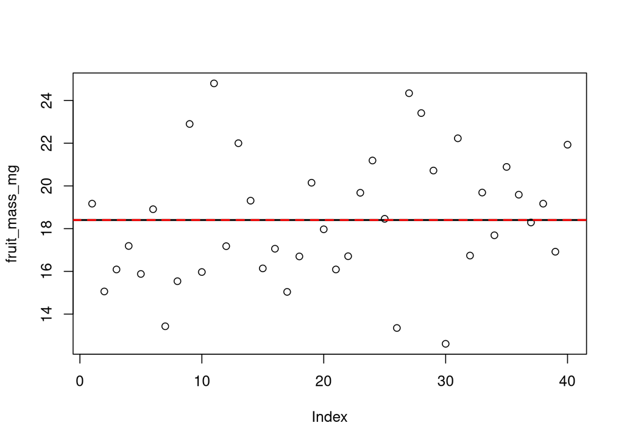

```r
plot(fruit_mass_mg ~ 1, data = weeds)
abline(null_mod, lwd = 2)
abline(h = mean(weeds$fruit_mass_mg), col = 'red', lty = 2, lwd = 2)
```

Note above that the x-axis is just an index of the 40 samples. The function `abline` is useful to specifying regression (`reg=`), horizontal (`h=`), and vertical lines (`v=`).

#### Main effect models

A main effect model is a model that includes at least one independent variable:

$$y = \beta_0 +
\beta_1x+\varepsilon$$

We can develop single *main effect* models that include either treatment or plant height as such in R:

```r
trt_mod <- lm(fruit_mass_mg ~ trt, data = weeds)
# alternatively we can just update null_mod
trt_mod <- update(null_mod, . ~ . + trt)
ht_mod <- update(null_mod, . ~ . + plant_ht_cm)
trt_mod
```

```
##
## Call:
## lm(formula = fruit_mass_mg ~ trt, data = weeds)
##
## Coefficients:
##     (Intercept)  trtunfertilized
##           20.10            -3.39
```

```r
ht_mod
```

```
##
## Call:
## lm(formula = fruit_mass_mg ~ plant_ht_cm, data = weeds)
##
## Coefficients:
## (Intercept)  plant_ht_cm
##     10.1205       0.3143
```

Let’s take a closer look at the `trt_mod` which includes the main effect due to treatment. Note that only one of the levels of treatment is provided as a coefficient. In this case it is `unfertilized`. To better understand this you need to consider how factor variables are included in regression models. A categorical variable is encoded in R into a set of orthogonal contrasts (aka [dummy variables](https://ordination.okstate.edu/envvar.htm)).

```r
levels(weeds$trt)
```

```
## [1] "fertilized"   "unfertilized"
```

```r
contrasts(weeds$trt)
```

```
##              unfertilized
## fertilized              0
## unfertilized            1
```

In this case we have a factor `trt` that only has two levels so it only requires one binary variable because if a sample is not fertilized then it must be unfertilized. That may seem a little strange but just remember that if you have a factor with *k* levels then you need *k* - 1 binary variables to specify that factor as a set of orthogonal contrasts. This explains why the treatment variable only requires a single regression coefficient.

Sometimes we have factors that are ranked such as low, medium, high. In this case the variable is called **ordinal** as opposed to our **nominal** treatment variable which did not contain ranks. The contrasts of ordinal variables are not as simple to specify and typically a Helmert polynomial contrasts are used (if you want to know more and possibly a better solution see [Gullickson’s 2020 blog post](https://aarongullickson.netlify.app/post/better-contrasts-for-ordinal-variables-in-r/))

Let’s examine these models graphically.

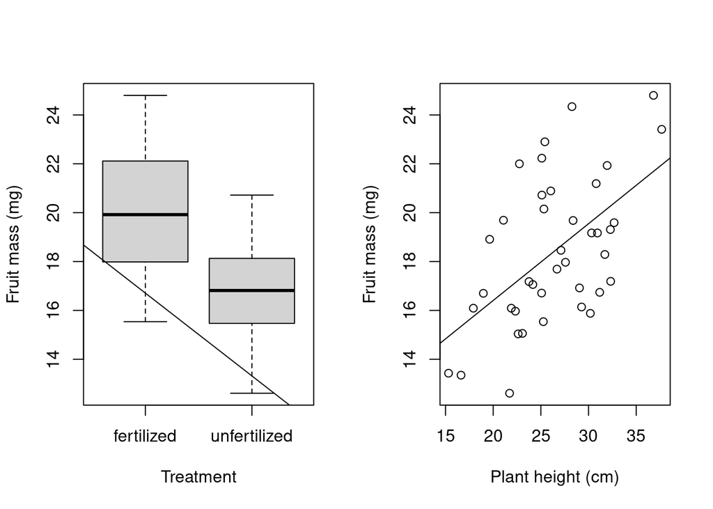

```r
par(mfrow=c(1,2))
plot(fruit_mass_mg ~ trt, data = weeds, xlab = 'Treatment',ylab = 'Fruit mass (mg)')
abline(trt_mod)

plot(fruit_mass_mg ~ plant_ht_cm, data = weeds,
     xlab = 'Plant height (cm)', ylab = 'Fruit mass (mg)')
abline(ht_mod)
```

The first panel of this graphic doesn’t quite look correct because the regression line is not intersecting the center of the boxplots which is what we would expect. This is because by default R assigns the first level of the treatment factor an x-value of 1 and the second level of the factor a value of 2. Therefore when the regression line is added to the plot it is plotting the y-intercept (which is the mean value of the fertilized group) off the graph to the left one unit. To correct this we have to build the graph from scratch a bit more carefully making sure that the fertilized group is plotted an an x-axis value of 0 so that the regression line intersects that groups properly.

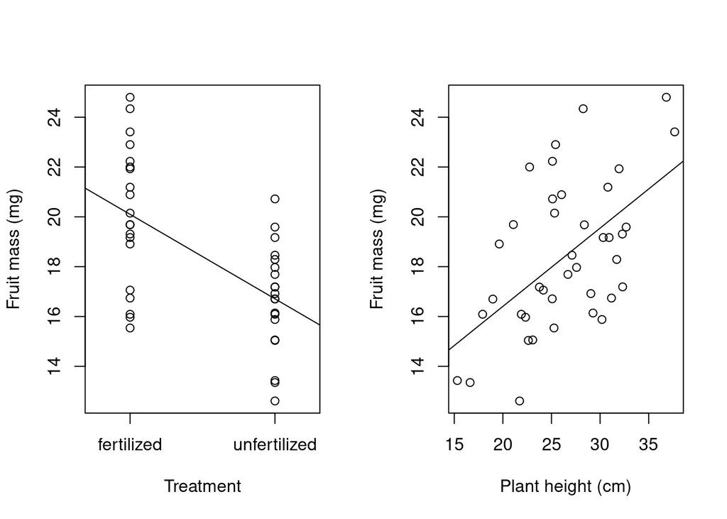

```r
par(mfrow=c(1,2))
plot(0:1, 0:1, type='n', ylim = range(weeds$fruit_mass_mg), axes = F,
     xlim = c(-0.25, 1.25),
     xlab = 'Treatment', ylab = 'Fruit mass (mg)', frame.plot = T)
points(rep(0, 20), weeds$fruit_mass_mg[weeds$trt == 'fertilized'])
points(rep(1, 20), weeds$fruit_mass_mg[weeds$trt == 'unfertilized'])
axis(side = 1, at = 0:1, labels = c('fertilized', 'unfertilized'))
axis(side = 2)
abline(trt_mod)

plot(fruit_mass_mg ~ plant_ht_cm, data = weeds,
     xlab = 'Plant height (cm)', ylab = 'Fruit mass (mg)')
abline(ht_mod)
```

This is a good example of how `ggplot` can simplify things if you know the correct command. In this case the command is a bit cryptic we need to specify in the mapping of the points that the argument `group = 1`. To be honest I’m not exactly sure what this means but a search of the internet suggested it would work so viola!

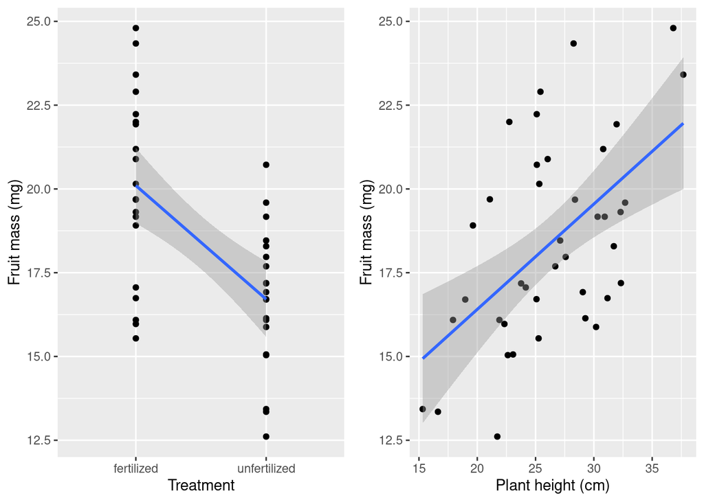

```r
p1 <- ggplot(data = weeds,
             mapping = aes(x = trt, y = fruit_mass_mg, group = 1)) +
      geom_point() +
      geom_smooth(method = 'lm') +
      labs(x = 'Treatment', y = 'Fruit mass (mg)')

p2 <- ggplot(data = weeds,
             mapping = aes(x = plant_ht_cm, y = fruit_mass_mg)) +
      geom_point() +
      geom_smooth(method = 'lm') +
      labs(x = 'Plant height (cm)', y = 'Fruit mass (mg)')

grid.arrange(p1, p2, nrow = 1)
```

Note above that the function `grid.arrange` is used to make multi-panel `ggplots` and it is a part of the `gridExtra` package.

#### All main effects model

Of course we can also specify a model that includes both main effects

$$y = \beta_0 + \beta_1x + \beta_2z +
\varepsilon$$

In R we would use:

```r
main_mod <- lm(fruit_mass_mg ~ trt + plant_ht_cm, data = weeds)
main_mod
```

```
##
## Call:
## lm(formula = fruit_mass_mg ~ trt + plant_ht_cm, data = weeds)
##
## Coefficients:
##     (Intercept)  trtunfertilized      plant_ht_cm
##         12.9586          -2.8822           0.2613
```

This particular model specifies two parallel regression lines that only differ in their y-intercept based on whether or not they were fertilized.

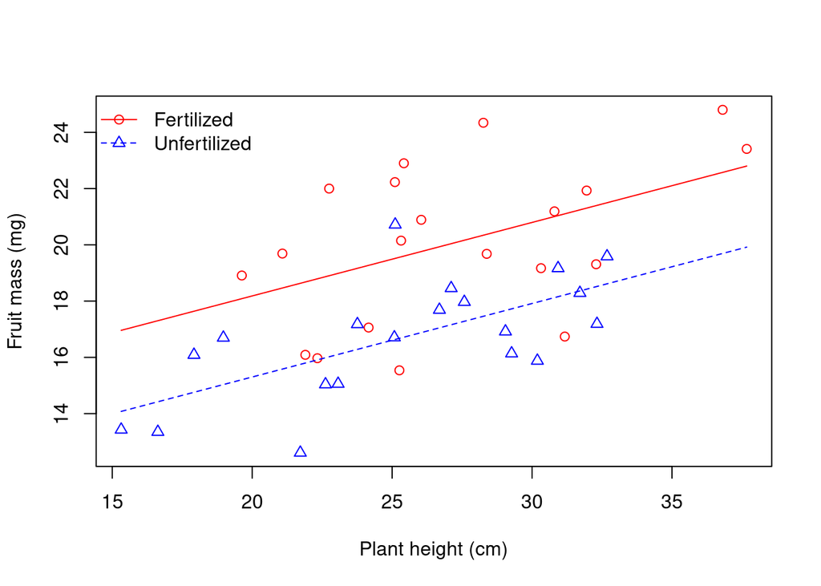

```r
# the traditional way to plot the fitted model predictions is to use the
# function predict
xrange <- range(weeds$plant_ht_cm)

plot(fruit_mass_mg ~ plant_ht_cm, data = weeds, type = 'n',
     xlab = 'Plant height (cm)', ylab = 'Fruit mass (mg)')
points(fruit_mass_mg ~ plant_ht_cm, data = weeds, subset = trt == "fertilized",
       pch = 1, col = 'red')
# add the fitted regression line using two points at either end of the range of x
lines(xrange,
      predict(main_mod,
              newdata = data.frame(plant_ht_cm = xrange, trt = "fertilized")),
      col = 'red', lty = 1)
points(fruit_mass_mg ~ plant_ht_cm, data = weeds, subset = trt == "unfertilized",
       pch = 2, col = 'blue')
lines(xrange,
      predict(main_mod,
              newdata = data.frame(plant_ht_cm = xrange, trt = "unfertilized")),
      col = 'blue', lty = 2)
legend('topleft', c('Fertilized', 'Unfertilized'), col = c('red', 'blue'),
       pch = c(1, 2), lty = c(1, 2), bty = 'n')
```

Above in the R code we used a new function `predict()`. This function is useful for taking a fitted model and using it to predict values. In this case we use this feature to predict where two points fall along the x-axis so that we can connect them with lines and thus form the fitted regression lines. One of the more difficult arguments to `predict()` to understand is the `newdata` argument. This is essentially a `data.frame` that must have the variables in the model included as column names. So in this case must have the variables `plant_ht_cm` and `trt` in `newdata`.

More recently the `marginaleffects` package has make it easier to generate plots of fitted models, for example:

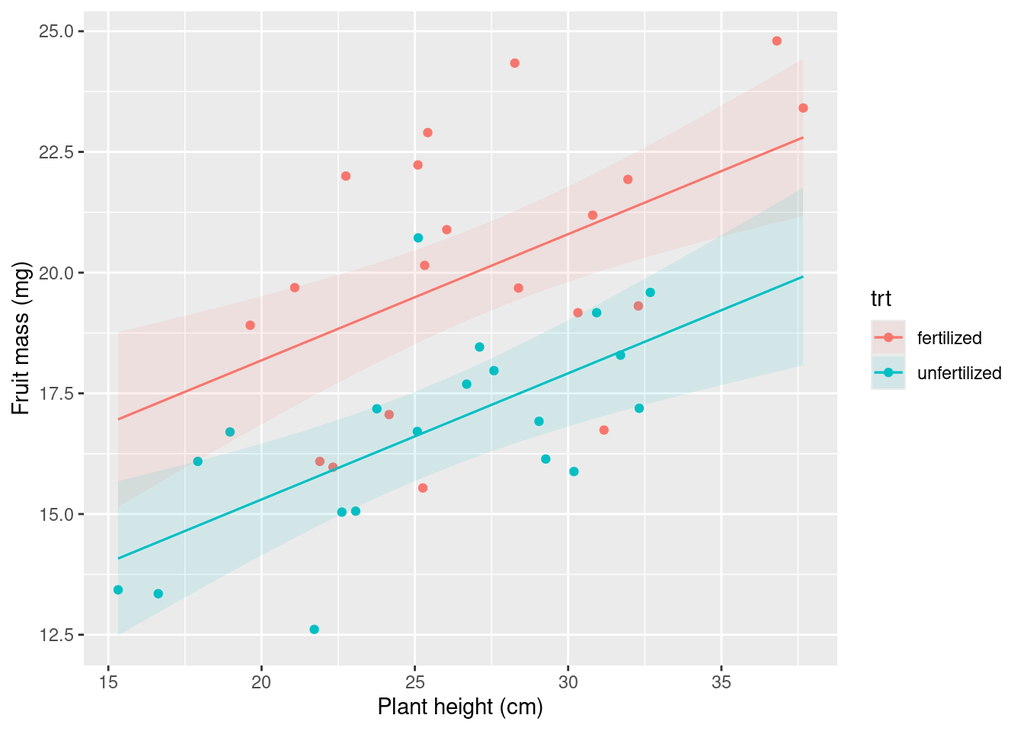

```r
plot_predictions(main_mod, condition = c('plant_ht_cm', 'trt'), points = 1) +
  xlab("Plant height (cm)") +
  ylab("Fruit mass (mg)")
```

As you can see the two approaches produce similar output but the newer approach is more efficient.

Another way to think about the main effect model is that it is specifying a 3d plane that can fit through the data.

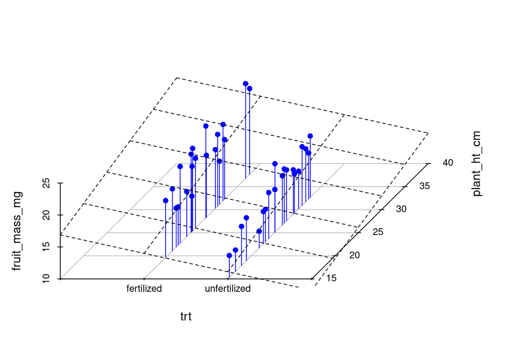

```r
s3d <- scatterplot3d(weeds[ , c('trt', 'plant_ht_cm', 'fruit_mass_mg')],
                     type = 'h', color = 'blue', angle = 65, pch = 16,
                     lab = c(3, 5), xlim = c(0, 3),
                     x.ticklabs = c('', 'fertilized', 'unfertilized', ''),
                     box = F)
# Add regression plane
s3d$plane3d(main_mod)
```

Again above it is a little fussy to make this graph because of the factor.

#### Interaction effect model

Lastly the most complex typical model that we would specify based on our graphical exploration would also be a model that includes an **interaction effect**. An interaction effect is an effect in which one variable influences the effect of another variable on the response.

$$y = \beta_0 + \beta_1x + \beta_2z +
\beta_3xz + \varepsilon$$

```r
int_mod <- lm(fruit_mass_mg ~ trt + plant_ht_cm + trt:plant_ht_cm,
              data = weeds)
# alternatively we can use * as short hand
int_mod <- lm(fruit_mass_mg ~ trt * plant_ht_cm, data = weeds)
int_mod
```

```
##
## Call:
## lm(formula = fruit_mass_mg ~ trt * plant_ht_cm, data = weeds)
##
## Coefficients:
##                 (Intercept)              trtunfertilized
##                   12.842466                    -2.669054
##                 plant_ht_cm  trtunfertilized:plant_ht_cm
##                    0.265532                    -0.008069
```

Graphically the easiest way to consider this model is that it specifies separate regression lines for each level of fertilization that differ in both their y-intercept and slope.

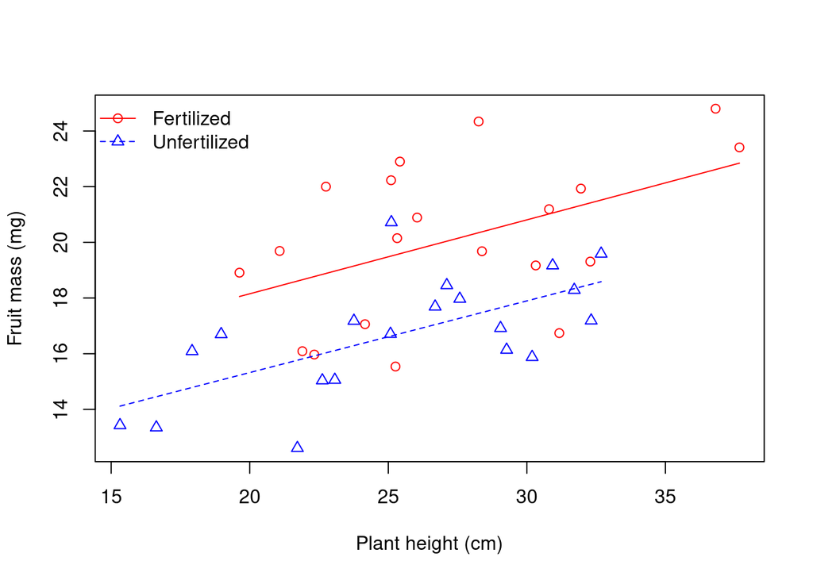

```r
plot(fruit_mass_mg ~ plant_ht_cm, data = weeds, type = 'n',
     xlab = 'Plant height (cm)', ylab = 'Fruit mass (mg)')
points(fruit_mass_mg ~ plant_ht_cm, data = weeds, subset = trt == "fertilized",
       pch = 1, col = 'red')
xrange <- range(weeds$plant_ht_cm[weeds$trt == "fertilized"])
lines(xrange,
      predict(int_mod,
              newdata = data.frame(plant_ht_cm = xrange, trt = "fertilized")),
      col = 'red', lty = 1)
points(fruit_mass_mg ~ plant_ht_cm, data = weeds, subset = trt == "unfertilized",
       pch = 2, col = 'blue')
xrange <- range(weeds$plant_ht_cm[weeds$trt == "unfertilized"])
lines(xrange,
      predict(int_mod,
              newdata = data.frame(plant_ht_cm = xrange, trt = "unfertilized")),
      col = 'blue', lty = 2)
legend('topleft', c('Fertilized', 'Unfertilized'), col = c('red', 'blue'),
       pch = c(1, 2), lty = c(1, 2), bty = 'n')
```

Or more efficiently we can simply use:

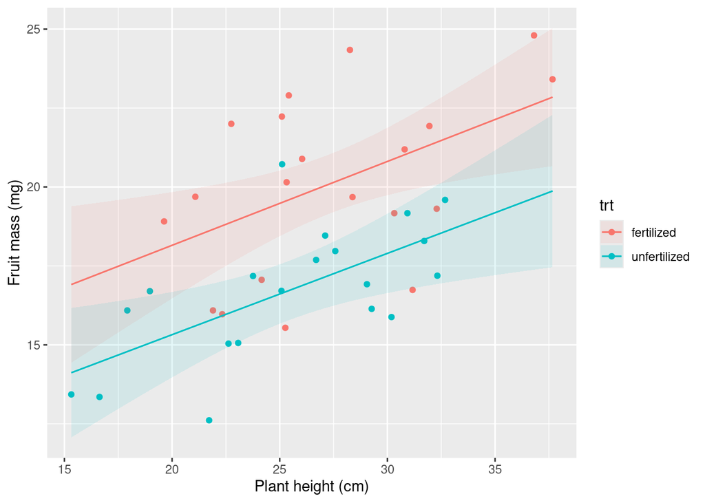

```r
plot_predictions(int_mod, condition = c('plant_ht_cm', 'trt'), points = 1) +
  xlab('Plant height (cm)') +
  ylab('Fruit mass (mg)')
```

##### **Exercise**

Try to come up with the `ggplot` code to graphically depict the interaction effect model (clue: we made essentially this graphic above but with a smoother so if you need a reminder of how to structure the code look above).

[Show answer]

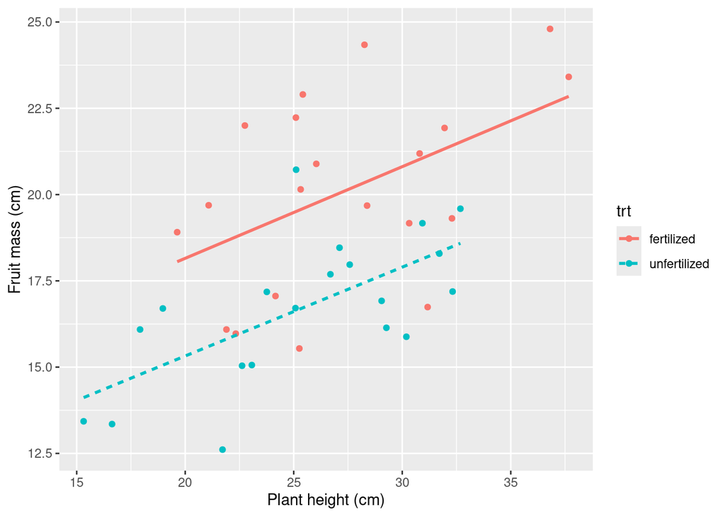

```r
ggplot(weeds, mapping = aes(x = plant_ht_cm, y = fruit_mass_mg)) +
  geom_point(aes(color = trt)) +
  geom_smooth(aes(color = trt, linetype = trt), method = 'lm', se = F) +
  labs(x = 'Plant height (cm)' , y = "Fruit mass (cm)")
```

##### **Question**

In the above graphic do you see good evidence that the additional complexity of the interaction effect model is warranted?

[Show answer]

```
The interaction effect model allows for the slopes of the lines to differ
based on fertilization but it can be seen that the best fit lines appear to have
very similar slopes which suggests that the added complexity is likely not
warrented
```

## # Tabular model interpretation

Now that we’ve build our two models let’s examine the model fits and the statistical significance of the explanatory variables.

```r
summary(trt_mod)
```

```
##
## Call:
## lm(formula = fruit_mass_mg ~ trt, data = weeds)
##
## Residuals:
##     Min      1Q  Median      3Q     Max
## -4.5600 -1.3049  0.0252  1.7704  4.7000
##
## Coefficients:
##                 Estimate Std. Error t value Pr(>|t|)
## (Intercept)      20.1000     0.5557  36.171  < 2e-16 ***
## trtunfertilized  -3.3905     0.7859  -4.314  0.00011 ***
## ---
## Signif. codes:  0 '***' 0.001 '**' 0.01 '*' 0.05 '.' 0.1 ' ' 1
##
## Residual standard error: 2.485 on 38 degrees of freedom
## Multiple R-squared:  0.3288, Adjusted R-squared:  0.3111
## F-statistic: 18.61 on 1 and 38 DF,  p-value: 0.0001099
```

```r
# because trt is a factor lets also examine the anova output
anova(trt_mod)
```

```
## Analysis of Variance Table
##
## Response: fruit_mass_mg
##           Df Sum Sq Mean Sq F value    Pr(>F)
## trt        1 114.95 114.955  18.614 0.0001099 ***
## Residuals 38 234.68   6.176
## ---
## Signif. codes:  0 '***' 0.001 '**' 0.01 '*' 0.05 '.' 0.1 ' ' 1
```

The function `summary` provides several useful pieces of information for linear models. The coefficients table:

```
Coefficients:
                Estimate Std. Error t value Pr(>|t|)
(Intercept)      20.1000     0.5557  36.171  < 2e-16 ***
trtunfertilized  -3.3905     0.7859  -4.314  0.00011 ***
```

which provides the estimate, standard error, t-statistic, and p-value for:

- $\hat{\beta_0}$ the y-intercept - 1st row of the table
- $\hat{\beta_1}$ the slope of the regression line - 2nd row of the table

The p-values can be used to assess statistical significance, and the t-statistics provide a measure of effect size.

**Note: most of the time we are not interested in the test of the intercept**

In addition to the coefficient table several statistics for the entire model are also provided:

```
Residual standard error: 2.485 on 38 degrees of freedom
Multiple R-squared:  0.3288,    Adjusted R-squared:  0.3111
F-statistic: 18.61 on 1 and 38 DF,  p-value: 0.0001099
```

The multiple R-squared and adjusted R-squared provide estimates of variance explained. The later statistic adjusts for the number of variables included in the model. The F-statistic is a ratio of the mean sum of squares for the model to the sum of squares of the residuals (i.e., the ratio of explained variance to unexplained variance). The p-value associated with the F-statistic provides a means of examining the statistics significance of the entire model.

**Note: in this specific model because only a single explanatory variable is included the overall model *p*-value is identical to the *p*-value reported for `trt` in the coefficients table.**

The function `anova` reports the analysis of variance table

```
Response: fruit_mass_mg
          Df Sum Sq Mean Sq F value    Pr(>F)
trt        1 114.95 114.955  18.614 0.0001099 ***
Residuals 38 234.68   6.176
```

```r
# F is explained SS / (unexplained SS / df)
114.95 / (234.68 / 38)
```

```
## [1] 18.613
```

Note that the *p*-value derived from the *F*-test is identical to the *t* reported for in the coefficient table returned by `summary`.

So the tabular output of the treatment main effect model indicates that including just treatment explains 31% of the variance which is a statistically significant amount of variance.

Now let’s examine the plant height main effect model

##### **Question**

Extract and interpret the model statistics for the plant height only model.

[Show answer]

```r
summary(ht_mod)
```

```
##
## Call:
## lm(formula = fruit_mass_mg ~ plant_ht_cm, data = weeds)
##
## Residuals:
##     Min      1Q  Median      3Q     Max
## -4.3367 -1.8466 -0.6624  1.8441  5.3379
##
## Coefficients:
##             Estimate Std. Error t value Pr(>|t|)
## (Intercept) 10.12052    2.09707   4.826 2.28e-05 ***
## plant_ht_cm  0.31428    0.07808   4.025 0.000262 ***
## ---
## Signif. codes:  0 '***' 0.001 '**' 0.01 '*' 0.05 '.' 0.1 ' ' 1
##
## Residual standard error: 2.54 on 38 degrees of freedom
## Multiple R-squared:  0.2989, Adjusted R-squared:  0.2804
## F-statistic:  16.2 on 1 and 38 DF,  p-value: 0.0002623
```

```r
# variance explained is 30% and overall model is statistically significant
# this suggests that the treatment effect is stronger than the plant height effect
```

## # Model comparisons

Our graphical exploration suggested that the model that included both treatment and plant height would have the most support let’s undertake some formal model comparison.

### Adjusted $R^2$

A simple but somewhat cumbersome approach is just to compare the model output from `summary`

```r
summary(main_mod)
```

```
##
## Call:
## lm(formula = fruit_mass_mg ~ trt + plant_ht_cm, data = weeds)
##
## Residuals:
##     Min      1Q  Median      3Q     Max
## -4.3628 -1.3944  0.3798  1.1516  4.0827
##
## Coefficients:
##                 Estimate Std. Error t value Pr(>|t|)
## (Intercept)     12.95862    1.86798   6.937 3.44e-08 ***
## trtunfertilized -2.88217    0.68014  -4.238 0.000144 ***
## plant_ht_cm      0.26128    0.06612   3.951 0.000336 ***
## ---
## Signif. codes:  0 '***' 0.001 '**' 0.01 '*' 0.05 '.' 0.1 ' ' 1
##
## Residual standard error: 2.112 on 37 degrees of freedom
## Multiple R-squared:  0.528,  Adjusted R-squared:  0.5025
## F-statistic: 20.69 on 2 and 37 DF,  p-value: 9.297e-07
```

```r
summary(int_mod)
```

```
##
## Call:
## lm(formula = fruit_mass_mg ~ trt * plant_ht_cm, data = weeds)
##
## Residuals:
##    Min     1Q Median     3Q    Max
## -4.379 -1.371  0.367  1.162  4.082
##
## Coefficients:
##                              Estimate Std. Error t value Pr(>|t|)
## (Intercept)                 12.842466   2.705632   4.747 3.25e-05 ***
## trtunfertilized             -2.669054   3.612254  -0.739  0.46476
## plant_ht_cm                  0.265532   0.097429   2.725  0.00985 **
## trtunfertilized:plant_ht_cm -0.008069   0.134256  -0.060  0.95241
## ---
## Signif. codes:  0 '***' 0.001 '**' 0.01 '*' 0.05 '.' 0.1 ' ' 1
##
## Residual standard error: 2.141 on 36 degrees of freedom
## Multiple R-squared:  0.528,  Adjusted R-squared:  0.4887
## F-statistic: 13.42 on 3 and 36 DF,  p-value: 4.907e-06
```

From this we can see that two models have identical $R^2$ values which usually would be surprising because we typically expect more complex models to have higher raw variance explained estimates. This isn’t surprising to use because we already graphically inspected the models and concluded there was little support for an interaction effect. We should also compare the adjusted $R^2$ which adjusts the estimate of variance explained based on how much we would expect the variance explained if purely noise variables were added. In this case the more complex interaction effect model has a lower adjust $R^2$ suggesting that it is not the most parsimonious model.

### Log-ratio tests

We can also use the function `anova` to carry out log-ratio tests on nested models. Nested models are models in which the more complex model has all of the same parameters as the simple model and then some additional ones.

```r
anova(main_mod, int_mod)
```

```
## Analysis of Variance Table
##
## Model 1: fruit_mass_mg ~ trt + plant_ht_cm
## Model 2: fruit_mass_mg ~ trt * plant_ht_cm
##   Res.Df    RSS Df Sum of Sq      F Pr(>F)
## 1     37 165.04
## 2     36 165.02  1  0.016559 0.0036 0.9524
```

The ANOVA table indicates that the interaction model does not explain significantly more variance - this case this was a silly test to run because we already could have predicted this result based on the adjusted $R^2$ values.

### AIC model comparison

In the biological sciences a popular way of comparing models is to use a penalized log likelihood criteria such as as the Akaike information criterion (AIC) or the Bayesian information criterion (BIC). Unlike the ANOVA comparisons AIC and BIC can be used to compare models that are not nested. The formula for AIC is:

$$\mathrm{AIC} = - 2\log(\hat L) + 2k$$

where $\hat L$ is the likelihood of the model and $k$ is the number of parameters in the model. The AIC index ranks models both on their degree of fit but also on their complexity. A small value of AIC indicates a better model and thus models with more complexity (i.e., more parameters) and thus larger $k$ value, but equal likelihood are considered worse models (higher AIC).

**Note: the exact value of the AIC model is not important but the differences between models are**

```r
# examine the AIC scores of all the models we have considered
# smaller number is better
AIC(null_mod)
```

```
## [1] 204.2357
```

```r
AIC(trt_mod)
```

```
## [1] 190.2891
```

```r
AIC(ht_mod)
```

```
## [1] 192.0322
```

```r
AIC(main_mod)
```

```
## [1] 178.2068
```

```r
AIC(int_mod)
```

```
## [1] 180.2027
```

So as you can see all the models are better than the null model, but the main effect only model is considered the best model. If two models are within 2 units of the AIC index then they are considered roughly equivalent models.

There is another function called `extractAIC` which returns different values for AIC because it uses different additive constants; however, the differences between the models are still the same

```r
AIC(main_mod)
```

```
## [1] 178.2068
```

```r
extractAIC(main_mod)[2]
```

```
## [1] 62.69167
```

```r
AIC(main_mod) - AIC(int_mod)
```

```
## [1] -1.995986
```

```r
extractAIC(main_mod)[2] - extractAIC(int_mod)[2]
```

```
## [1] -1.995986
```

### Model diagonstics

Now that we think we have a sufficient model (i.e., the main effect model) we should carefully examine it to make sure it meets the assumptions of OLS regression. This is particularly important if we are going to use the *p*-values for rigorous hypothesis testing.

It is easy to examine the diagnostics of the model visually using `plot`

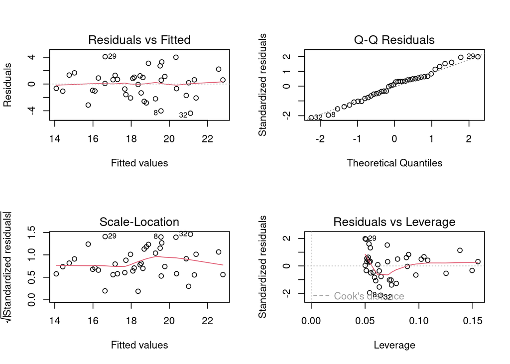

```r
par(mfrow = c(2,2))
plot(main_mod)
```

The top left and bottom left panels both suggests that the assumption of **homoscedasticity** holds. The top right panel suggests that the residuals are **normally distributed**. The bottom right panel suggests that there are not large outliers that are having a disproportionate effect on the regression.

### Biological conclusion: Fruit size increases due to fertizlier and plant height

We have carried out model comparison and checked the model assumptions, we can now feel pretty confident about making some biological conclusions.

Our main effect model received the most empirical support and it suggests that fruit mass increased due to fertilizer and plant height (see figure below). The effect of fertilizer was a little stronger than the effect of height and together these two variables helped to explain approximately 50% of the variance in fruit mass. We did not find that the effects of plant height on fruit mass depended on if the plant was fertilized.

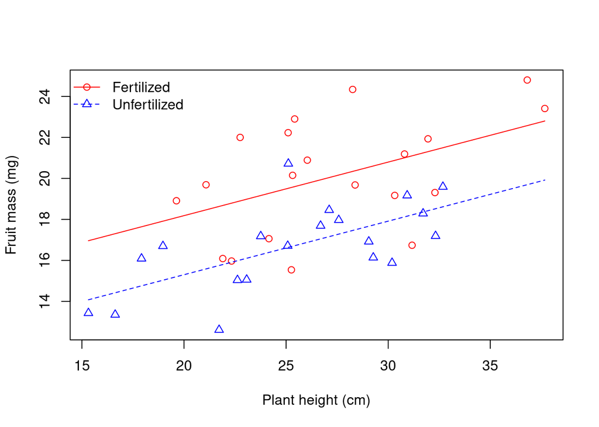

Above is the final best supported model (source code for this is provided when the main effect model is first introducted above)

### Automated model selection

The approach we have taken above of a careful examination of the graphical patterns in the data set followed by careful and rational model comparison is not always possible when the models being compared are quite large. However, this method does suffer from Freedman’s paradox discussed at the top of the lesson.

```r
# run a stepwise regression analysis on the full model.
stepAIC(int_mod)
```

```
## Start:  AIC=64.69
## fruit_mass_mg ~ trt * plant_ht_cm
##
##                   Df Sum of Sq    RSS    AIC
## - trt:plant_ht_cm  1  0.016559 165.04 62.692
## <none>                         165.02 64.688
##
## Step:  AIC=62.69
## fruit_mass_mg ~ trt + plant_ht_cm
##
##               Df Sum of Sq    RSS    AIC
## <none>                     165.04 62.692
## - plant_ht_cm  1    69.644 234.68 74.774
## - trt          1    80.098 245.13 76.517
```

```
##
## Call:
## lm(formula = fruit_mass_mg ~ trt + plant_ht_cm, data = weeds)
##
## Coefficients:
##     (Intercept)  trtunfertilized      plant_ht_cm
##         12.9586          -2.8822           0.2613
```

As you can see above this approach results in the same model that we found to be the best - the main effects model. Do note that `stepAIC` internally uses the function `extracAIC` to compute the AIC values.